# NERTutorial

Nole Lin

November 6, 2017

## Named Entity Recognition (NER)

Named Entity Recognition (NER) is a subtask of information extraction that seeks to locate and classify named entities in text into pre-defined categories such as the names of persons, organizations, etc.

For example, consider this block of text:

> Jim bought 300 shares of Acme Corp. in 2006.

The annotated block of text would look like this:

> [Jim]<sub>Person</sub> bought 300 shares of [Acme Corp.]<sub>Organization</sub> in [2006]<sub>Time</sub>.

### How to Perform NER?

NERs are usually implemented using Conditional Random Fields (CRF). So let’s take a detour and learn about CRFs.

#### Conditional Random Fields

A CRF is a type of classifier that takes into account the order of the data being presented. This is helpful because we can determine how likely a word will have which tag, depending on the previous word in the sentence. To build a CRF, we need to construct a set of **feature functions** $f_i$

##### Feature Functions in a CRF

A feature function is a function that takes in as input:

- a sentence s
- the position i of a word in the sentence
- the label $l_i$ of the current word
- the label $l_{i-1}$ of the previous word

and outputs a number.

##### Features to Probabilities

Next, assign each feature function $f_j$ a weight $\lambda_j$. Given a sentence s, we can now score a labeling l of s by adding up the weighted features over all words in the sentence:

$score(l | s) = \sum_{j = 1}^m \sum_{i = 1}^n \lambda_j f_j(s, i, l_i, l_{i-1})$

Finally, we can transform these scores into probabilities $p(l | s)$ between 0 and 1 by exponentiating and normalizing:

$p(l | s) = \frac{exp[score(l|s)]}{\sum_{l’} exp[score(l’|s)]} = \frac{exp[\sum_{j = 1}^m \sum_{i = 1}^n \lambda_j f_j(s, i, l_i, l_{i-1})]}{\sum_{l’} exp[\sum_{j = 1}^m \sum_{i = 1}^n \lambda_j f_j(s, i, l’_i, l’_{i-1})]}$

##### Example Feature Function

So what do these feature functions look like? An example of NER-labeled features could include:

- $f_1(s, i, l_i, l_{i-1}) = 1$ if (i-1)th word is “named” and $l_i =$ Person; 0 otherwise.

A positive weight for this feature would mean that the entity Person tends to follow the word “named.” For example, consider the sentence: “This man is named Peter.”

And that’s it! To sum up: to build a conditional random field, you just define a bunch of feature functions (which can depend on the entire sentence, a current position, and nearby labels), assign them weights, and add them all together, transforming at the end to a probability if necessary.

##### Learning Weights

One way to learn the weights is to use gradient descent.

Assume we have a bunch of training examples (sentences and associated entity labels). Randomly initialize the weights of our CRF model. To shift these randomly initialized weights to the correct ones, for each training example…

- Go through each feature function $f_i$, and calculate the gradient of the log probability of the training example with respect to $\lambda_i$: $\frac{\partial}{\partial w_j} \log p(l | s) = \sum_{j = 1}^m f_i(s, j, l_j, l_{j-1}) - \sum_{l’} p(l’ | s) \sum_{j = 1}^m f_i(s, j, l’_j, l’_{j-1})$
- Note that the first term in the gradient is the contribution of feature $f_i$ under the true label, and the second term in the gradient is the expected contribution of feature $f_i$ under the current model. This is exactly the form you’d expect gradient ascent to take.
- Move $\lambda_i$ in the direction of the gradient: $\lambda_i = \lambda_i + \alpha [\sum_{j = 1}^m f_i(s, j, l_j, l_{j-1}) - \sum_{l’} p(l’ | s) \sum_{j = 1}^m f_i(s, j, l’_j, l’_{j-1})]$ where $\alpha$ is some learning rate.
- Repeat the previous steps until some stopping condition is reached (e.g., the updates fall below some threshold).

In other words, every step takes the difference between what we want the model to learn and the model’s current state, and moves $\lambda_i$ in the direction of this difference.

##### Finding the Optimal Labeling

Suppose we’ve trained our CRF model, and now a new sentence comes in. How do we do label it?

The naive way is to calculate $p(l | s)$ for every possible labeling l, and then choose the label that maximizes this probability. However, since there are $k^m$ possible labels for a tag set of size k and a sentence of length m, this approach would have to check an exponential number of labels.

A better way is to use polynomial-time dynamic programming algorithm to find the optimal label, similar to Viterbi algorithm for Hidden Markov Models but we won’t go into that.

## NER in Spark

To perform NER in Spark, start the Spark Shell with the command:

`./spark-shell --packages JohnSnowLabs:spark-nlp:1.2.3`

Then import the necessary objects:

```
import com.johnsnowlabs.nlp._
import com.johnsnowlabs.nlp.annotators._
import org.apache.spark.ml.Pipeline
```

SparkNLP first requires you to get your document annotated with the transformer DocumentAssembler.

We’ll use the Article_Mesh DataFrame as our example.

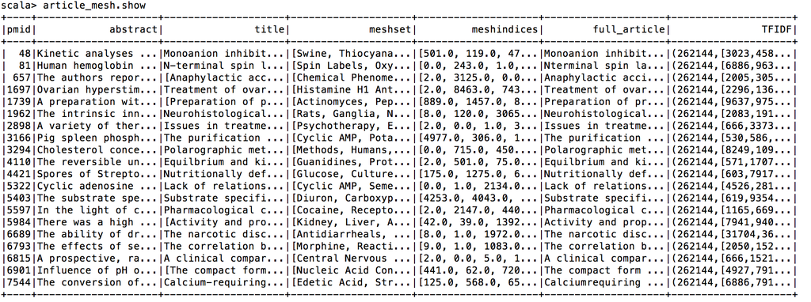

Now create the DocumentAssembler object and transform `article_mesh`.

```
val documentAssembler = new DocumentAssembler().setInputCol("full_article").setOutputCol("document")
val res1 = documentAssembler.transform(article_mesh)
```

Looking at the result of the transformation on a random article:

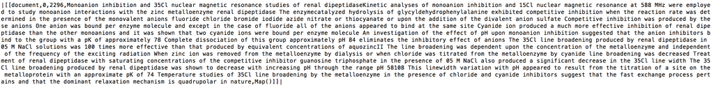

The first element of the array is “document”, which indicates the type of annotator. In our case, it’s the Document Annotator. Next, we see 0 and 2296, which indicate the beginning and end indices of our raw text. Finally, we have the actual content of the document.

Now we can use the NER tool to identify entities. The NER annotator requires a dictionary corpus that maps words to their labels. An example of this in a text file would be:

```
NaCl: drug
```

Moving on with the code:

```
import com.johnsnowlabs.nlp.annotators.ner.regex.NERRegexApproach
val nerTagger = new NERRegexApproach().setInputCols(Array("document")).setOutputCol("ner").setCorpusPath("/Users/nolelin/Downloads/dict.txt")
val res4 = nerTagger.fit(res1).transform(res1)
res4.select("ner").show(1, truncate=false)
```

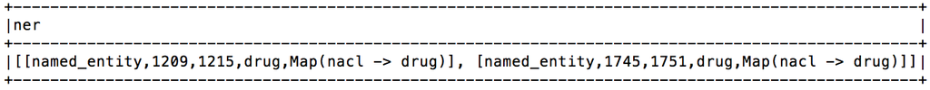

Now we see the indicator “named_entity,” representing the NER annotator. The pairs of indices show where in the text “NaCl” was found for our example document above. Lastly, the Map gives us the word and its proper label.

Thus, we have implement NER on a document within Spark.